# DB24.402

[מרכז המיקרוביום שיבא - תל־השומר](https://bit.ly/microbiome_il)

תאריך עדכון הדו”ח: 12/09/2023

[figure not shown]

# מבוא לבדיקה או: מה בעצם אנחנו עושים פה?

לא פחות מטריליוני תאי חיידקים (מיקרוביוטה) שוכנים במעיים שלנו, כשבכל אחד ואחת מאיתנו, שוכנת אוכלוסיית חיידקים ייחודית. במהלך השנים האחרונות, הצטברו לא מעט עדויות המצביעות על כך שאותם טריליוני חיידקים, למעשה מסייעים בעיכול מרכיבי מזון, מרסנים או מפעילים את מערכת החיסון במידת הצורך ונקשרים למצבי בריאות וחולי שונים. למעשה, על פי מחקרים ייתכן ולאוכלוסיית חיידקי המעיים של כל אחד ואחת מאיתנו השפעה על מגוון רחב של מצבים רפואיים:

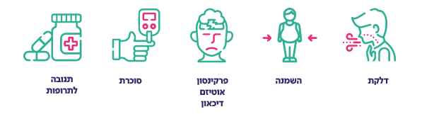

מרתק? לגמרי. אבל למרות שלא מעט כבר התגלה, נושא חיידקי המעיים ממשיך להיות מסתורי. כדי שנוכל להמשיך ולחקור וגם להגיע לפריצות דרך בתחום, אנו זקוקים למידע נוסף שבעתיד עשוי לסייע לנו למנוע מחלות ואפילו לרפא אותן. וכאן זה המקום להגיד לך תודה על הנכונות לתרום להתקדמות המחקר. דגימות ממספר משתתפים גדול ומגוון, יאפשר לנו להתקדם משמעותית בדרך לפיצוח חיידקי המעיים והמשמעות שלהם עבורנו – ועל הדרך ילמד אותך כמה עובדות מרתקות על חיידקי המעיים האישיים שלך.

### אז מה מחכה לך בדו”ח האישי

- הדו”ח מרכז אפיון של אוכלוסיית חיידקי המעי האישית שלך, שהותוותה באמצעות שיטות מולקולריות ואנליזה חישובית.
- אוכלוסיית החיידקים שלך מושווית בדו”ח לנתונים שנאספו מקבוצת ישראלים מבוגרים ובריאים, המנותחת באופן דומה ומתעדכנת לעיתים קרובות. **בדו”ח נגלה לך איפה ממוקמת אוכלוסיית חיידקי המעי שלך ביחס לקבוצה זו של מבוגרים בריאים בישראל וביחס לקבוצות נוספות, בעלות מאפיינים מוגדרים, לדוגמה כאלה שאוכלים מעט או הרבה פירות וירקות.**

- הדו”ח אישי ועוסק באוכלוסיית החיידקים במעי. אין מדובר בחוות דעת רפואית. חשוב להדגיש: תוצאות גבוהות או נמוכות מהנורמה לא מעידות בהכרח על בעיה. על פי המידע שיש בידינו כרגע, ערכים אלה עשוים להופיע גם במצב תקין לחלוטין.
- כחלק מהמעקב, יש חשיבות לביצוע דיגום חוזר. יש לכך משמעות גדולה במיוחד אם ביצעת שינוי בהרגלי התזונה, הפעילות הגופנית או הרגלי העישון, נוכל בהמשך לבצע לך דיגום חוזר ואז נשווה בין התוצאות שהתקבלו בפרקי זמן שונים. דיגום מחדש יכול לספק תמונה מעניינת במיוחד במקרה של שינוי באורח החיים.

### קרוב-רחוק: השוואות לאוכלוסיות חיידקים של אחרים

מה עשינו פה בעצם: השתמשנו בנתונים ממחקרים שנעשו באוכלוסיות שונות ברחבי העולם ובאמצעות חישוב המרחק הממוצע, השווינו את הדמיון בין כל אחד מהפרטים לקבוצות השונות המוצגות במחקר. איך זה עובד? הנה הסבר קצר שיעזור לך בקריאת והבנת הנתונים:

- ההיסטוגרמה (צורת הצגת הנתונים בגרף) בצבע סגול: מייצגת את הדגימות בקבוצת הביקורת הישראלית ואת המרחק של הנבדקים בקבוצה זו, בהשוואה לאותם תנאים ספציפיים (לדוגמה, אכילת ירקות) בקבוצות הנבדקות (אלה שאוכלים הרבה ירקות ואלה שאוכלים מעט ירקות).
- ההיסטוגרמות הירוקות והאדומות: מייצגות את הדמיון (מרחק) של אותם תנאים בקבוצת המקוריות (לדוגמה, כאלה שאוכלים מעט או הרבה ירקות).
- הנקודה שלך (הצהובה) מציינת את הקירבה (דמיון) לתנאים אלה, כלומר ככל שהיא קרובה יותר לאחד ממרכזי ההיסטוגרמות, כך היא דומה יותר לאותה הקבוצה ולהפך.

תזונה: YOU ARE WHAT YOU EAT

#01

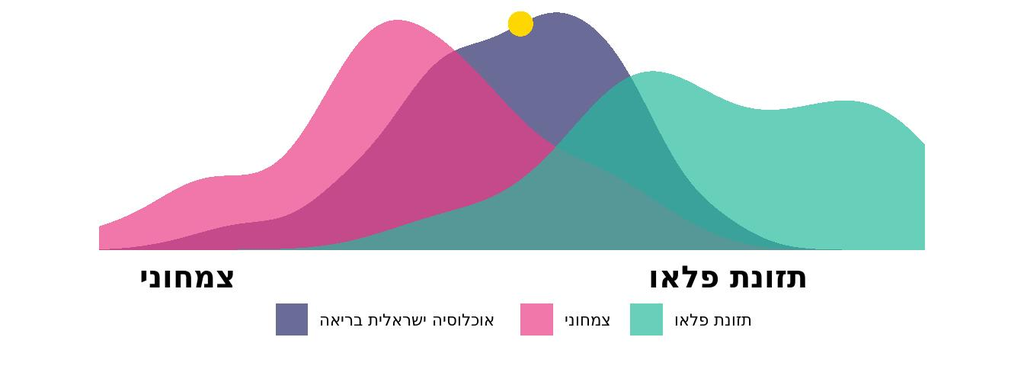

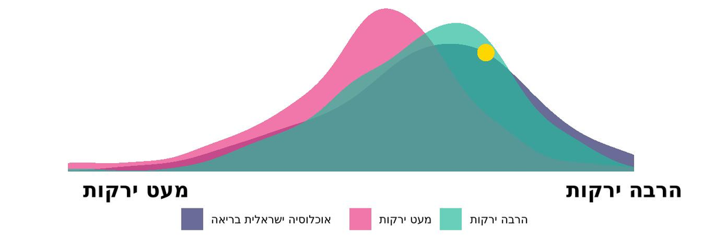

במחקר תצפיתי<sup>2</sup> בו בדקו את אוכלוסיית החיידקים של אנשים לאחר ששאלו אותם שאלון מקיף התגלה שיש שוני בין אנשים שאכלו מעט ירקות לאנשים שאכלו הרבה ירקות.

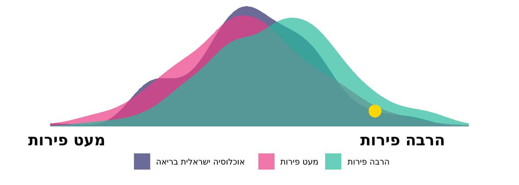

במחקר תצפיתי<sup>2</sup> בו בדקו את אוכלוסיית החיידקים של אנשים לאחר ששאלו אותם שאלון מקיף התגלה שיש שוני בין אנשים שאכלו מעט פירות לאנשים שאכלו הרבה פירות.

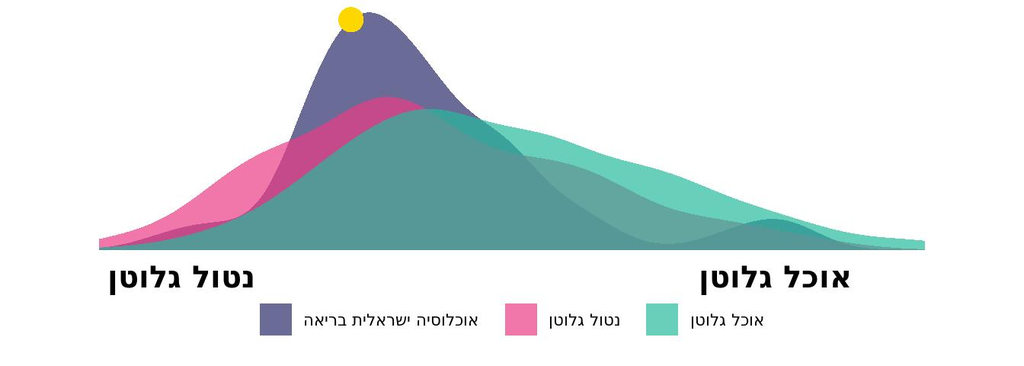

במחקר תצפיתי<sup>2</sup> בו בדקו את אוכלוסיית החיידקים של אנשים לאחר ששאלו אותם שאלון מקיף התגלה שיש שוני בין אנשים שאכלו תזונה המכילה גלוטן לבין אנשים הנמנעים מגלוטן בתזונה.

דמוגרפיה

#02

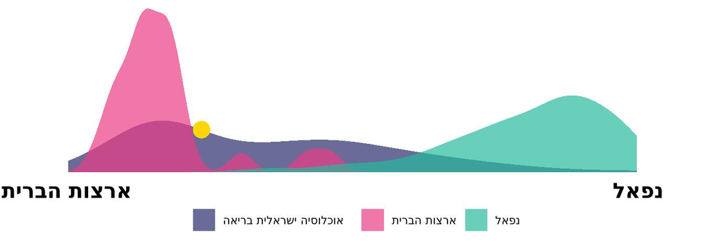

במחקר<sup>3</sup> שהשווה בין חיידקים של אנשים מנפאל לעומת אנשים מארצות הברית ראו הבדלים משמעותיים בין אוכלוסיות החיידקים של שתי הקבוצות.

מדד בריאות כללי

#03

המדד פותח כאן, במרכז המיקרוביום בשיבא, לאחר בדיקה של אנשים בריאים ואנשים חולים במחלות שונות מרחבי העולם. מה עשינו: אפיינו את החיידקים שנמצאים בתדירות ושכיחות גבוהה יותר אצל בריאים לעומת חולים במחלות שונות ומגוונות כמו מחלות מעיים דלקתיות, פרקינסון ומחלות אחרות. הראינו שהמדד נמוך יותר בקרב אנשים עם מחלות שונות בהשוואה לאנשים בריאים. חשוב להגיד: עדיין לא ברור האם הרכב המיקרוביום משפיע על המחלה או משקף את מצבה. ישנה שונות במדד זה בקרב אנשים בריאים ואנשים חולים ולכן לא ניתן לחזות באופן מהימן את מצב המחלה (חולי) ברמה האישית.

לקריאה נוספת:<sup>4</sup>

| מהמדגם שבידינו, ל-**90%** מהאוכלוסיה יש ציון נמוך משלך. | לפי המידע שבידינו, הציון שלך גם גבוה ביותר מאשר **96%** מהחולים. הנקודה הצהובה מציינת את מיקומך |
| --- | --- |

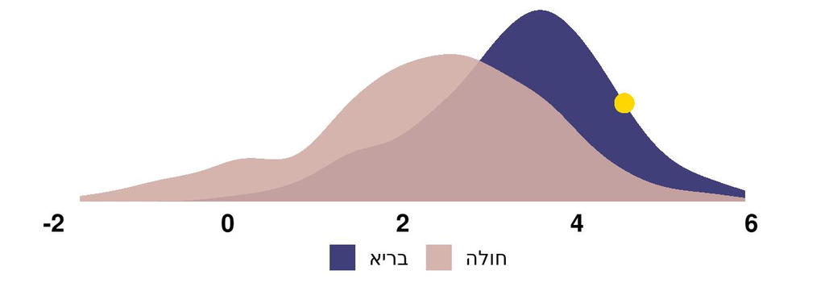

מגוון החיידקים במעיים

#04

מגוון אוכלוסיית חיידקי המעיים שלך, נקשר גם הוא למצבי בריאות וחולי. המדד מאפיין כמה מיני חיידקים יש לך. ככלל, עושר מינים גבוה, מעיד על שונות גבוהה ואוכלוסייה מגוונת, תופעה שמקושרת למצב בריא יותר. הגרף ממקם אותך בנוגע לעושר המינים ביחס לקבוצת הבריאים הישראלית (הנקודה הצהובה מייצגת את הציון שלך).

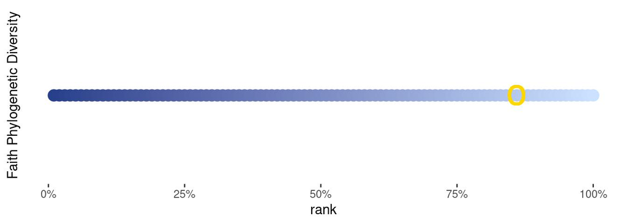

מדד עושר המינים שלך (במדד Faith) גבוה יותר מ-**87%** מהאוכלוסייה הבריאה בישראל.

מבנה קהילת החיידקים (טקסונומיה): כאן גרים בכיף

#05

**חיידקי המעי חיים כקהילה** החיידקים השונים מקיימים אינטראקציות זה עם זה ועם האדם. כדי להצליח ולאפיין את הקהילה, נוצרו סיווגים טקסונומיים שבהם ממלכת החיידקים מחולקת למספר קטגוריות עיקריות. **בתרשים המעגל הבא, אפשר לראות את התפלגות המינים בקבוצה הבריאה הכללית ולצידה את קהילת חיידקי המעיים שלך.** כדי לקבל סיווג ספציפי יותר, החיידקים מחולקים גם לחלוקה מצומצמת יותר, כך שכל מערכה (Phylum) מכילה מספר מחלקות ובצורה יותר ספציפית: סדרה > משפחה > סוג > מין

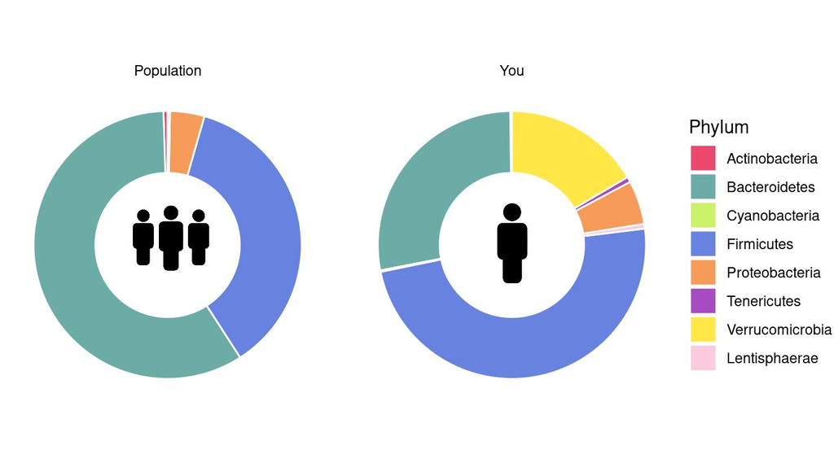

בגרפים הבאים נציג מספר מיני חיידקים ואת היחס ביניהם, שעל פי מחקרים שנערכו בעבר הם בעלי משמעות מיוחדת.

#### Bacteroidetes / Firmicutes ratio

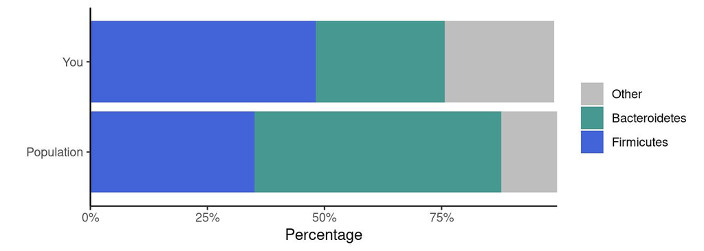

מערכות החיידקים הנפוצות ביותר הן של חיידקי Bacteroidetes ו-Firmicutes. מחקרים שנעשו בעבר הראו<sup>5</sup> שהיחס בין כמויות החיידקים מסוג זה, משקפות מצב של משקל עודף ומצבים דלקתיים שונים. חיידקים מסוג Bacteroides נצפו כמקושרים עם תזונה עשירה בחלבון מן החי ושומן רווי. לעומתם, חיידקים מסוג Prevotella, נצפו כקשורים לתזונה עשירה בעמsעמילן, סיבים וחלבון צמחי ודלה בשומן וחלבון מן החי. ובכל זאת, עדיין דרושים מחקרים נוספים לצורך ביסוס הטענות האלה. בגרף הבא אנו מציגים את כמות חיידקי ה-Bacteroidetes וה-Firmicutes שלך.

לקריאה נוספת:<sup>6</sup>

#### Bacteroides / Prevotella ratio

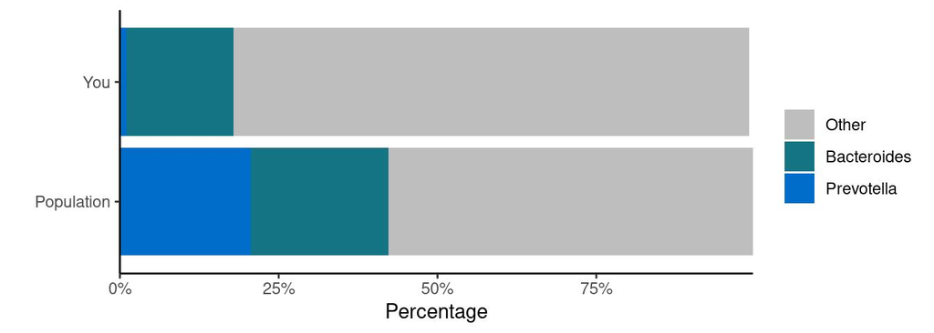

### עשרת הגדולים: החיידקים הנפוצים שלך

איך קוראים לעשרת החיידקים בעלי השכיחות הגבוהה ביותר במעיים שלך ומהו האחוז הממוצע של כל חיידק בקרב אנשים אחרים עם אותם חיידקים ספציפיים? אז ככה: **החלק התחתון בגרף:** מראה את שכיחות החיידק באוכלוסייה. **החלק העליון בגרף:** מראה את השכיחות בדגימה שלך לעומת השכיחות באלה שלהם אותו החיידק.

**מקרא:**

- Phyla=P – מערכה
  - Class=C – מחלקה
    - Order=O – סדרה
      - Family=F – משפחה
        - Genus=G – סוג
          - Species=S – זן

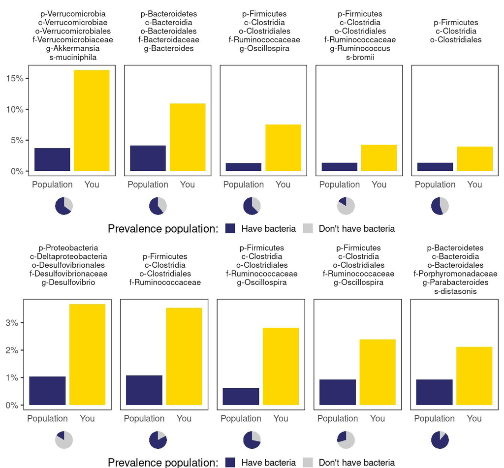

### משוב

נשמח לקבל משוב למידע בדו”ח זה בקישור המצורף: [משוב](https://akwe.short.gy/zJDiP7)

### ביבליוגרפיה

1.

Turnbaugh PJ, Bäckhed F, Fulton L, Gordon JI. Diet-induced obesity is linked to marked but reversible alterations in the mouse distal gut microbiome. Cell host & microbe [Internet] 2008; 3:213–23. Available from: https://www.sciencedirect.com/science/article/pii/S1931312808000899

2.

McDonald D, Hyde E, Debelius JW, Morton JT, Gonzalez A, Ackermann G, Aksenov AA, Behsaz B, Brennan C, Chen Y, et al. American gut: An open platform for citizen science microbiome research. Msystems [Internet] 2018; 3:e00031–18. Available from: https://journals.asm.org/doi/10.1128/mSystems.00031-18

3.

Jha AR, Davenport ER, Gautam Y, Bhandari D, Tandukar S, Ng KM, Fragiadakis GK, Holmes S, Gautam GP, Leach J, et al. Gut microbiome transition across a lifestyle gradient in himalaya. PLoS biology [Internet] 2018; 16:e2005396. Available from: https://journals.plos.org/plosbiology/article?id=10.1371/journal.pbio.2005396

4.

Abbas-Egbariya H, Haberman Y, Braun T, Hadar R, Denson L, Gal-Mor O, Amir A. Meta-analysis defines predominant shared microbial responses in various diseases and a specific inflammatory bowel disease signal. Genome Biology [Internet] 2022; 23:1–23. Available from: https://genomebiology.biomedcentral.com/articles/10.1186/s13059-022-02637-7

5.

Hills RD, Pontefract BA, Mishcon HR, Black CA, Sutton SC, Theberge CR. Gut microbiome: Profound implications for diet and disease. Nutrients [Internet] 2019; 11. Available from: https://www.mdpi.com/2072-6643/11/7/1613

6.

Ley RE, Turnbaugh PJ, Klein S, Gordon JI. Human gut microbes associated with obesity. nature [Internet] 2006; 444:1022–3. Available from: https://www.nature.com/articles/4441022a